# 扩充至两个转折点

之前的模型是我们假设有一个转折点，从而估计转折点在哪一天。但有没有可能不止一个转折点呢？下面我们将转折点个数进行扩充，假如有2个转折点。

接下来进行建模。和之前的几乎一样。

（1）短信数量符合泊松分布。泊松分布十分适合描述某段时间内，事件具体的发生概率。

$$ C_i \sim \text{Poisson}(\lambda) $$

（2）确定泊松分布参数$\lambda$的先验分布。

$$ \lambda = \begin{cases} \lambda_1 & \text{if } t \lt \tau_1 \cr \lambda_2 & \text{if } \tau_1 \le t \lt \tau_2 \cr \lambda_3 & \text{if } t \ge \tau_2 \end{cases} $$\begin{align} &\lambda_1 \sim \text{Exp}( \alpha ) \\\ &\lambda_2 \sim \text{Exp}( \alpha )\\\ &\lambda_3 \sim \text{Exp}( \alpha ) \end{align}

（3）确定$\tau_1$和$\tau_2$的先验

将上述分布转换为代码

```python
import pymc3 as pm
import numpy as np
import matplotlib.pyplot as plt

count_data = np.loadtxt("txtdata.csv")
n_count_data = len(count_data)
```

```python
model=pm.Model()
with model:
    alpha = 1.0 / count_data.mean() #1/短信的平均值
    #随机变量的先验，这里三个先验一样
    lambda_1 = pm.Exponential("lambda_1", alpha)

    lambda_2 = pm.Exponential("lambda_2", alpha)

    lambda_3= pm.Exponential("lambda_3", alpha)

    tau1 = pm.DiscreteUniform("tau1", lower=0, upper=n_count_data-1)

    tau2=pm.DiscreteUniform("tau2", lower=tau1, upper=n_count_data)
```

接下来需要得到$\lambda$

此处需注意，在原先的例子里使用了

$$lambda_ = pm.math.switch(tau >= idx, lambda_1, lambda_2)$$

一个类似于if语句的Theano函数。它使用第一个参数在后面的两个参数之间切换。而此处需要$if,elif,else$的结构完成分段函数。单独的$switch$语句是无法完成的。

```python
with model:
    idx = np.arange(n_count_data)  # Index，当前天数

    lambda_temp = pm.math.switch(tau1 >= idx , lambda_1,lambda_2)

    lambda_ = pm.math.switch(tau2 >= idx,lambda_temp,lambda_3 )

    observation = pm.Poisson("obs", lambda_, observed=count_data)
```

--------($\lambda_1$)---------$\tau_1$--------($\lambda_2$)------$\tau_2$------($\lambda_3$)-------

#### MCMC采样

```python
with model:

    trace = pm.sample(10000,tune=2000,cores=1)
```

```
Sequential sampling (2 chains in 1 job)
CompoundStep
>NUTS: [lambda_3, lambda_2, lambda_1]
>CompoundStep
>>Metropolis: [tau2]
>>Metropolis: [tau1]
There were 31 divergences after tuning. Increase `target_accept` or reparameterize.
The number of effective samples is smaller than 10% for some parameters.
```

```python
pymc3.sampling.sample(draws=500, step=None, init='auto', n_init=200000, start=None, trace=None, chain_idx=0, chains=None, cores=None, tune=500, progressbar=True, model=None, random_seed=None, discard_tuned_samples=True, compute_convergence_checks=True, **kwargs)
```

draws (int): 采样个数

The number of samples to draw. Defaults to 500. The number of tuned samples are discarded by default.

step : 采样器

A step function or collection of functions.If there are variables without step methods, step methods for those variables will be assigned automatically. By default the NUTS step method will be used, if appropriate to the model; this is a good default for beginning users.

chains(int): 采样链的个数

The number of chains to sample. Running independent chains is important for some convergence statistics and can also reveal multiple modes in the posterior. If None, then set to either cores or 2, whichever is larger.

cores (int): 并行的链的个数

The number of chains to run in parallel. If None, set to the number of CPUs in the system, but at most 4.

tune (int): 调整的迭代次数。类似预烧期？

Number of iterations to tune, defaults to 500. Samplers adjust the step sizes, scalings or similar during tuning. Tuning samples will be drawn in addition to the number specified in the draws argument, and will be discarded unless discard_tuned_samples is set to False.

抽取$(10000+2000)*2=24000$个样本

step表示选取的采样方法，例如：NUTS, Metropolis, Slice, HamiltonianMC, and BinaryMetropolis trace收集到的采样值存储在 Trace 对象中，按照采样值获得的先后顺序存储。

关于采样器：

二值变量：指定 BinaryMetropolis

离散变量：指定 Metropolis

连续变量：指定 NUTS NUTS基于对数概率密度的梯度，利用了高概率密度的区域信息，以获得比传统采样算法更快的收敛速度

**当step自己指定：**

```python
with model:
    step=Metropolis()
    trace = pm.sample(10000,tune=2000,cores=1,step=step)
```

[figure not shown]

**当chains 和cores的取值默认时**

[figure not shown]

https://docs.pymc.io/api/inference.html?highlight=sample#inference

pymc3提供了 traceplot 函数来绘制后验采样的趋势图

```
array([[<matplotlib.axes._subplots.AxesSubplot object at 0x0000023448C9CE10>,
      dtype=object)
```

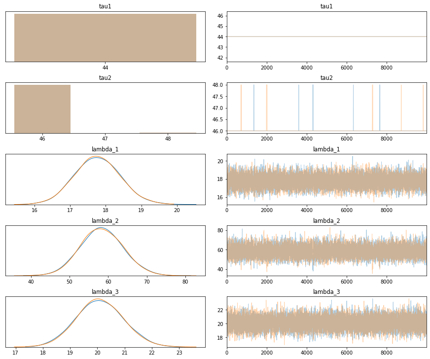

```python
import warnings
warnings.filterwarnings("ignore")#这里感谢叶凌云介绍warnings的库，去掉了警告，不然有些影响观感
pm.traceplot(trace)
```

左侧是每个随机变量的边际后验的直方图，使用核密度估计进行了平滑处理。右侧是马尔可夫链采样值按顺序绘制。对于向量参数 beta 会有两条后验分布直方图和后验采样值。

```python
lambda_1_samples = trace['lambda_1']
lambda_2_samples = trace['lambda_2']
lambda_3_samples = trace['lambda_3']
tau1_samples = trace['tau1']
tau2_samples = trace['tau2']
```

**当discard_tune_samples的默认值为True时$\tau_1$和$\tau_2$ 的采样结果**

trace里是移除了预烧期采样的样本

```python
import collections
print(lambda_1_samples.shape[0])
print(lambda_2_samples.shape[0])
print(lambda_3_samples.shape[0])
print(collections.Counter(tau1_samples))
print(collections.Counter(tau2_samples))
```

```
20000
20000
20000
Counter({44: 20000})
Counter({46: 19843, 48: 157})
```

**当discard_tune_samples 的值为False时的采样结果**

trace里是包含了了预烧期采样的样本

```python
with model:
    trace = pm.sample(10000,tune=2000,discard_tuned_samples=False,cores=1)
```

[figure not shown]

### 得到各个参数后验的均值

```python
print(lambda_1_samples.mean())
print(lambda_2_samples.mean())
print(lambda_3_samples.mean())
print(tau1_samples.mean())
print(tau2_samples.mean())
```

```
17.767620395327747
58.38418735924896
20.102326934753776
44.0
46.0157
```

### 可视化参数

官方文档 https://matplotlib.org/

相关直方图的一篇博客 https://my.oschina.net/u/2474629/blog/1793008

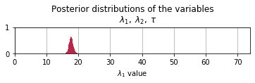

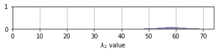

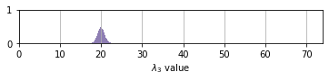

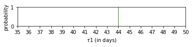

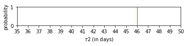

```python
ax = plt.subplot(511)#3行1列
ax.set_autoscaley_on(False)

plt.hist(lambda_1_samples, histtype='stepfilled', bins=30, alpha=0.85,
         label="posterior of $\lambda_1$", color="#A60628", density=True)

plt.title(r"""Posterior distributions of the variables
    $\lambda_1,\;\lambda_2,\;\tau$""")
plt.xlim([0, n_count_data])
plt.xlabel("$\lambda_1$ value")
plt.grid(True)
plt.show()

ax = plt.subplot(512)
ax.set_autoscaley_on(False)
plt.hist(lambda_2_samples, histtype='stepfilled', bins=30, alpha=0.85,
         label="posterior of $\lambda_2$", color="#7A68A6", density=True)

plt.xlim([0,n_count_data])
plt.xlabel("$\lambda_2$ value")
plt.grid(True)

plt.show()

ax = plt.subplot(513)
ax.set_autoscaley_on(False)
plt.hist(lambda_3_samples, histtype='stepfilled', bins=30, alpha=0.85,
         label="posterior of $\lambda_3$", color="#7A68A6", density=True)
plt.xlim([0, n_count_data])
plt.xlabel("$\lambda_3$ value")
plt.grid(True)

plt.show()

plt.subplot(514)
ax.set_autoscaley_on(False)
w = 1.0 / tau1_samples.shape[0] * np.ones_like(tau1_samples)
plt.hist(tau1_samples, bins=n_count_data, alpha=1,
         label=r"posterior of $\tau$",
         color="#467821", weights=w, rwidth=2)
plt.xticks(np.arange(n_count_data))
plt.ylim([0, 1])
plt.xlim([35, 50])
plt.xlabel(r"$\tau1$ (in days)")
plt.ylabel("probability")

plt.show()

plt.subplot(515)
ax.set_autoscaley_on(False)
w = 1.0 / tau2_samples.shape[0] * np.ones_like(tau2_samples)
plt.hist(tau2_samples, bins=n_count_data, alpha=1,
         label=r"posterior of $\tau$",
         color="#467821", weights=w, rwidth=2)
plt.xticks(np.arange(n_count_data))
plt.ylim([0, 1])
plt.xlim([35, 50])
plt.xlabel(r"$\tau2$ (in days)")
plt.ylabel("probability")

plt.show()
```

### 结论

44 和 46 这两个分段点十分接近，模型有可能过拟合了。

### 每天短信数量的期望值

```python
expected_texts_per_day = np.zeros(n_count_data)
for day in range(0, n_count_data):
    ix_1 = day < tau1_samples
    ix_2 = (day > tau1_samples).all() and (day < tau2_samples).all()
    ix_3 = day > tau2_samples
    expected_texts_per_day[day] = (lambda_1_samples[ix_1].sum()+lambda_2_samples[ix_2].sum()+lambda_3_samples[ix_3].sum())/len(lambda_1_samples)
```

布尔索引,布尔值数组的长度必须和数组轴索引长度一致。

https://www.jianshu.com/p/cab82780d36b

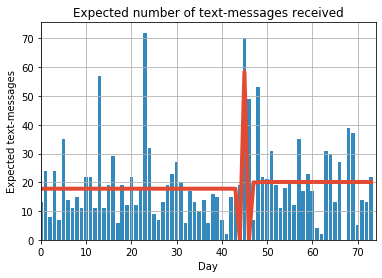

```python
plt.plot(range(n_count_data), expected_texts_per_day, lw=4, color="#E24A33",label="expected number ")
plt.xlim(0, n_count_data)
plt.xlabel("Day")
plt.ylabel("Expected text-messages")
plt.title("Expected number of text-messages received")
plt.bar(np.arange(n_count_data),count_data, color="#348ABD", label="observed texts per day")
plt.grid(True)
```

### 整个模型代码如下：

```python
import pymc3 as pm
import numpy as np
import matplotlib.pyplot as plt


count_data = np.loadtxt("txtdata.csv")
n_count_data = len(count_data)

with pm.Model() as model:
    alpha = 1.0 / count_data.mean() #1/短信的平均值
    lambda_1 = pm.Exponential("lambda_1", alpha)
    lambda_2 = pm.Exponential("lambda_2", alpha)
    lambda_3= pm.Exponential("lambda_3", alpha)
    tau1 = pm.DiscreteUniform("tau1", lower=0, upper=n_count_data-1)
    tau2=pm.DiscreteUniform("tau2", lower=tau1, upper=n_count_data)

    idx = np.arange(n_count_data)  # Index，当前天数
    lambda_temp = pm.math.switch(tau1 >= idx , lambda_1,lambda_2)
    lambda_ = pm.math.switch(tau2 >= idx,lambda_temp,lambda_3 )


    observation = pm.Poisson("obs", lambda_, observed=count_data)

    trace = pm.sample(10000, tune=2000,cores=1,chains=2)

pm.traceplot(trace)
```